# Intro to R Crash Course

Fred LaPolla

3/9/2022

## Intro to R: A Crash Course for Absolute Beginners

## R Notebooks

This file will walk you through every step of today’s class. Throughout the R notebook, you will see the example code displayed like this. Code can be run by hitting the Play button triangle. If your code has an error and you want to reset your code up to this point, the down arrow with a green line runs all code up to this point:

```r
print(2  +  2)
```

```
## [1] 4
```

## Objectives

Learning R is a journey, and you should not expect to walk out of one workshop with mastery. By the end of today’s class you should be able to:

1. Recognize R’s syntax and understand how to format an argument
2. Understand common sources of problems in R and how to troubleshoot them
3. Know where to look for more information
4. Be able to load in data from a csv
5. Be able to load a package and find information on its functions

## Getting Started

In this class, we are using an R Notebook RStudio, which is an integrated development environment (IDE).

## Scripting vs. Processing vs. Markdown

This class is taught using an R Notebook, which is a type of R Markdown file. It allows you to have text with embedded code. For example we can provide explanatory text and then offer a line of R code for you to execute. Try running the following code to do a simple math problem:

```r
2+2
```

```
## [1] 4
```

R Markdown files are primarily used for presenting your work to others. This class is using a type of markdown file called an R notebook. Markdown can be made into an HTML page, PDF or word document through a process called “knitting.” The difference between a Markdown file and a Notebook are how they execute the code (as a chunk vs line by line), but this is not a concern today.

## Scripting

If you are not writing code to be published and read in a narrative way, you may still want to have a file that saves comments and stores code. A script file is a common way to do this. Having a an R script will let you leave comments to yourself or others, provide a file for others to see what you have done, make your research more reproducible or rerun analyses.

To create a new R script, under the menus go to File -> New File -> R Script. This will open a file called Untitled1 in the upper left panel of R Studio. There are two types of things you can enter in this window: 1) Comments: any line that starts with a # is interpreted by R as a comment and is not processed 2) Commands: any line that does NOT start with a # is interpreted as a command and R will attempt to process it

Type the following into the script window:

```
# Create a vector x, or "list" of numbers (more on vectors later)
```

x <- c(1,2,5,6)

## Calculate the mean of x

mean(x)

Save the file as PracticeScript.R, and then run dir(). You should see that the script is now in your working directory. There are several ways you can run the contents of the script:

1. Copy and paste the commands you want to run into the Console panel
2. Select the commands you want to run and hit Ctrl-Enter
3. Select the commands you want to run and hit the Run button at the top (looks like a “play” button)
4. Run the source function: source(PracticeScript.R) to run the entire contents of the script.

## R Console

You can also type code directly into the console. This may be done as you are trying out work that may not want to save right away and are searching for the best solution. Then afterwards you can copy and paste it into the scripting pane to save for later. The console is like your scrap paper, good for working but not for saving.

In the R Console, you can use tab completion and up arrow to save typing!

Type the first part of command or variable name, you can scroll through the options that appear and hit tab to fill in the option you want.

Use up arrow to scroll back through commands. You can then re-run a previous command, or modify it and run a new command.

## Command line versus menu options

A number of functions can be executed either by typing in the Console or by using menu options. For example, the working directory is the folder R will look in for files, and you can set this working directory one of three ways:

1. Typing the function setwd() in the command line
2. choosing the “Set as Working Directory” option under the More button on the Navigation Pane
3. Selecting Session-> Set Working Directory from the top menu bar.

If you want to check what your current working directory is, use the command getwd:

```r
getwd()
```

```
## [1] "/Users/lapolf01/Documents/Education/February R"
```

## Working Directory

If you want to find out what files are in your current working directory is, use the command dir:

```r
dir()
```

```
## [1] "NYC_HANES_DIAB.csv"            "RCrashCourse_Feb22.html"
## [3] "RCrashCourse_Feb22.Rmd"        "RCrashCourse.Rmd"
## [5] "RCrashCourseGroupWork_Feb22.R"
```

## Reading in CSVs

Next we will read in our data, which is in a CSV file, but R can read almost any type of file. First, we can look at the help text for the function we will use.

The syntax “?[some function]” will open a help page if one exists. This is a great way to get a sense of what parts of a function or “arguments” are needed to run a function. Not all of the parts of a function listed in the help page will be necessary, most are optional. The best way to get a sense of what is needed is to see what others have done and trial and error.

```r
?read.csv
```

Note: There are many arguments but we only need to specify those for which the default value is not what we want.

## read.csv()

You can pull a CSV from a web source, as below, or if it is on your computer you can just run:

nyc <- read.csv(“yourFile.csv”“)

```r
nyc <- read.csv("https://raw.githubusercontent.com/fredlapolla/RCrashCourse/main/NYC_HANES_DIAB.csv")
```

## Troubleshooting and Understanding Errors

When you first get started with R, expect to see lots of error messages! Here are some helpful hints for troubleshooting some common errors.

Common error sources:

- Typos
- R is Case Sensitive. It is not space sensitive
- Unclosed parentheses or quotation marks
- Commas
- Arguments that a command does not know how to handle

If you see a + plus sign after your command, it means somewhere a parenthesis or quotation mark did not close.

Hit *escape* to clear the command and try again after looking for typos.

## Getting to Know Your Data

Back to the data frame you read into your Global Environment. How can you get a sense of what data we have in the NYC Hanes data frame looks like?

There are a several ways to explore the contents of the dataset. You could type in the name of the data frame, but unless your data frame is very small, that is probably not a good idea! If you do want to see the full data frame, you can click on the name of the data frame in the Environment pane this actually runs the following function:

(Here is a useful command that I must run in the console due to the R slidy slides not liking it)

**View(nyc)**

That is a lot of information to try to parse, but R has functions that allow you to find out useful information about the data frame. A good way to start is by calling the str() function with the name of the data frame as the argument. This function shows the structure of the data.

```r
str(nyc)
```

```
## 'data.frame':    1527 obs. of  23 variables:
##  $ KEY              : chr  "134040A" "134240B" "134460B" "134490A" ...
##  $ GENDER           : int  1 1 1 1 1 1 1 1 1 1 ...
##  $ SPAGE            : int  29 27 28 27 24 30 26 31 32 34 ...
##  $ AGEGROUP         : int  1 1 1 1 1 1 1 1 1 1 ...
##  $ HSQ_1            : int  2 2 2 2 1 1 3 1 2 1 ...
##  $ UCREATININE      : int  105 296 53 314 105 163 150 46 36 177 ...
##  $ UALBUMIN         : num  0.707 18 1 8 4 3 2 2 0.707 4 ...
##  $ UACR             : num  0.00673 6 2 3 4 ...
##  $ MERCURYU         : num  0.37 NA 0.106 0.487 2.205 ...
##  $ DX_DBTS          : int  3 3 3 3 3 3 3 3 3 3 ...
##  $ A1C              : num  5 5.5 5.2 4.8 5.1 4.3 5.2 4.8 5.2 4.8 ...
##  $ CADMIUM          : num  0.2412 0.4336 0.1732 0.0644 0.0929 ...
##  $ LEAD             : num  1.454 0.694 1.019 0.863 1.243 ...
##  $ MERCURYTOTALBLOOD: num  2.34 3.11 2.57 1.32 14.66 ...
##  $ HDL              : int  42 52 51 42 61 52 50 57 56 42 ...
##  $ CHOLESTEROLTOTAL : int  184 117 157 145 206 120 155 156 235 156 ...
##  $ GLUCOSESI        : num  4.61 4.5 4.77 5.16 5 ...
##  $ CREATININESI     : num  74.3 80 73 80 84.9 ...
##  $ CREATININE       : num  0.84 0.91 0.83 0.91 0.96 0.75 0.99 0.9 0.84 0.93 ...
##  $ TRIGLYCERIDE     : int  156 63 43 108 65 51 29 31 220 82 ...
##  $ GLUCOSE          : int  83 81 86 93 90 92 85 72 87 96 ...
##  $ COTININE         : num  31.5918 57.6882 0.0635 0.035 0.0514 ...
##  $ LDLESTIMATE      : int  111 52 97 81 132 58 99 93 135 98 ...
```

## Summary

Notice that this data frame has 1527 observations and 23 variables. Remember that observations correspond to the rows of the data frame and variables correspond to its columns.

You can get some basic summary statistics about your data using the command summary().

```r
summary(nyc)
```

```
##      KEY                GENDER         SPAGE          AGEGROUP
##  Length:1527        Min.   :1.00   Min.   :20.00   Min.   :1.000
##  Class :character   1st Qu.:1.00   1st Qu.:30.00   1st Qu.:1.000
##  Mode  :character   Median :2.00   Median :42.00   Median :2.000
##                     Mean   :1.58   Mean   :44.55   Mean   :1.749
##                     3rd Qu.:2.00   3rd Qu.:57.00   3rd Qu.:2.000
##                     Max.   :2.00   Max.   :97.00   Max.   :3.000
##
##      HSQ_1       UCREATININE       UALBUMIN             UACR
##  Min.   :1.00   Min.   :  1.0   Min.   :   0.707   Min.   :   0.002
##  1st Qu.:2.00   1st Qu.: 73.0   1st Qu.:   2.000   1st Qu.:   2.000
##  Median :3.00   Median :127.0   Median :   5.000   Median :   3.700
##  Mean   :2.62   Mean   :139.2   Mean   :  32.885   Mean   :  31.274
##  3rd Qu.:3.00   3rd Qu.:189.0   3rd Qu.:  12.000   3rd Qu.:   9.080
##  Max.   :5.00   Max.   :612.0   Max.   :4142.000   Max.   :5327.000
##  NA's   :1      NA's   :78      NA's   :84         NA's   :84
##     MERCURYU          DX_DBTS           A1C            CADMIUM
##  Min.   : 0.1060   Min.   :1.000   Min.   : 3.000   Min.   :0.0104
##  1st Qu.: 0.1060   1st Qu.:3.000   1st Qu.: 5.100   1st Qu.:0.1906
##  Median : 0.4173   Median :3.000   Median : 5.300   Median :0.2936
##  Mean   : 0.8141   Mean   :2.719   Mean   : 5.568   Mean   :0.4213
##  3rd Qu.: 0.9513   3rd Qu.:3.000   3rd Qu.: 5.700   3rd Qu.:0.4895
##  Max.   :27.3626   Max.   :3.000   Max.   :13.400   Max.   :3.9132
##  NA's   :119       NA's   :281     NA's   :323      NA's   :326
##       LEAD         MERCURYTOTALBLOOD       HDL         CHOLESTEROLTOTAL
##  Min.   : 0.2312   Min.   :  0.0919   Min.   : 23.00   Min.   : 95.0
##  1st Qu.: 0.7440   1st Qu.:  0.7564   1st Qu.: 44.00   1st Qu.:158.0
##  Median : 1.0576   Median :  1.6044   Median : 55.00   Median :183.0
##  Mean   : 1.3401   Mean   :  2.6162   Mean   : 57.32   Mean   :186.5
##  3rd Qu.: 1.6246   3rd Qu.:  3.1284   3rd Qu.: 67.00   3rd Qu.:210.0
##  Max.   :16.6202   Max.   :129.2344   Max.   :149.00   Max.   :357.0
##  NA's   :326       NA's   :326        NA's   :329      NA's   :329
##    GLUCOSESI       CREATININESI      CREATININE      TRIGLYCERIDE
##  Min.   : 3.108   Min.   : 34.00   Min.   :0.3800   Min.   : 11.0
##  1st Qu.: 4.551   1st Qu.: 60.00   1st Qu.:0.6800   1st Qu.: 52.0
##  Median : 4.880   Median : 70.72   Median :0.8000   Median : 78.0
##  Mean   : 5.284   Mean   : 73.88   Mean   :0.8358   Mean   : 99.4
##  3rd Qu.: 5.383   3rd Qu.: 82.80   3rd Qu.:0.9375   3rd Qu.:123.0
##  Max.   :27.195   Max.   :619.68   Max.   :7.0100   Max.   :821.0
##  NA's   :329      NA's   :329      NA's   :329      NA's   :330
##     GLUCOSE          COTININE        LDLESTIMATE
##  Min.   : 56.00   Min.   :  0.035   Min.   : 26.0
##  1st Qu.: 82.00   1st Qu.:  0.035   1st Qu.: 85.0
##  Median : 88.00   Median :  0.035   Median :106.0
##  Mean   : 95.24   Mean   : 37.689   Mean   :109.1
##  3rd Qu.: 97.00   3rd Qu.:  1.327   3rd Qu.:130.0
##  Max.   :490.00   Max.   :803.992   Max.   :246.0
##  NA's   :332      NA's   :332       NA's   :341
```

This displays different types of stats about each variable, depending on its type. For continuous variables, summary returns the mean, median, quartiles, minimum, maximum and count of NAs. For categorical variables, summary returns a count of how many items are in each category. Let us explore why this is by looking at the class of these variables. A variable is referred to using the date frame name, then $, and then the variable name.

## R holds several types of data:

- Numbers (e.g. 4.5, 100, etc.)
- Integer (writted 1L, meaning 1)
- Characters (string, e.g. “Fred”)
- Factor (categorical, e.g. “Population Health”, “DGIM”, and ordinal e.g. “PGY1”, “PGY2”, “PGY3” )
- Logical (e.g. True False)
- Complex (e.g. 1+i, probably this does not matter)

## Let’s take a look

```r
class(nyc$AGEGROUP)
```

```
## [1] "integer"
```

Does this seem right?

Let’s fix it:

```r
nyc$AGEGROUP<- factor(nyc$AGEGROUP, levels = 1:3, labels = c("20-39", "40-59", "60+"), ordered = TRUE)
```

## Exercise:

Reclassify DX_DBTS, a variable that holds three groups, 1) Diabetes with a diagnosis; 2) Diabetes with no diagnosis and 3) No Diabetes.

## R holds several structures of data

- Dataframes - Analogous to a spreadsheet, columns and rows of different types of data
- Matrices - Columns and rows of all one type of data (e.g. all numeric)
- Lists - A collection of objects that do not need to be the same type
- Vectors - A collection of objects of the same type (like a list)

Depending on what types of analysis you are doing, the difference could be important

## Exercise:

What type of structure is nyc?

The functions head() or tail() allow you to look at the first or last rows of a data frame. You can specify how many rows are displayed (default is 6 rows).

```r
head(nyc, n=5)
```

```
##       KEY GENDER SPAGE AGEGROUP HSQ_1 UCREATININE UALBUMIN        UACR
## 1 134040A      1    29    20-39     2         105    0.707 0.006733333
## 2 134240B      1    27    20-39     2         296   18.000 6.000000000
## 3 134460B      1    28    20-39     2          53    1.000 2.000000000
## 4 134490A      1    27    20-39     2         314    8.000 3.000000000
## 5 134620A      1    24    20-39     1         105    4.000 4.000000000
##    MERCURYU DX_DBTS A1C CADMIUM   LEAD MERCURYTOTALBLOOD HDL CHOLESTEROLTOTAL
## 1 0.3703090       3 5.0  0.2412 1.4540            2.3394  42              184
## 2        NA       3 5.5  0.4336 0.6938            3.1074  52              117
## 3 0.1060000       3 5.2  0.1732 1.0194            2.5700  51              157
## 4 0.4870047       3 4.8  0.0644 0.8634            1.3178  42              145
## 5 2.2051570       3 5.1  0.0929 1.2434           14.6634  61              206
##   GLUCOSESI CREATININESI CREATININE TRIGLYCERIDE GLUCOSE COTININE LDLESTIMATE
## 1    4.6065       74.256       0.84          156      83  31.5918         111
## 2    4.5000       80.000       0.91           63      81  57.6882          52
## 3    4.7700       73.000       0.83           43      86   0.0635          97
## 4    5.1600       80.000       0.91          108      93   0.0350          81
## 5    4.9950       84.864       0.96           65      90   0.0514         132
```

You can also generate a frequency table with the command table:

```r
table(nyc$AGEGROUP)
```

```
##
## 20-39 40-59   60+
##   697   516   314
```

The function names() returns a list of the variables or column names in our dataset. This is useful if you need to check the spelling or capitalization of variables, or to find out the column number that corresponds to a variable (you can refer to a column by its number or name).

```r
names(nyc)
```

```
##  [1] "KEY"               "GENDER"            "SPAGE"
##  [4] "AGEGROUP"          "HSQ_1"             "UCREATININE"
##  [7] "UALBUMIN"          "UACR"              "MERCURYU"
## [10] "DX_DBTS"           "A1C"               "CADMIUM"
## [13] "LEAD"              "MERCURYTOTALBLOOD" "HDL"
## [16] "CHOLESTEROLTOTAL"  "GLUCOSESI"         "CREATININESI"
## [19] "CREATININE"        "TRIGLYCERIDE"      "GLUCOSE"
## [22] "COTININE"          "LDLESTIMATE"
```

# Processing and Working with Data

In this section, you will learn to use R to do some basic processing and cleaning of data (data wrangling) in order to make it easier to work with.

## Indexing

Often, you will not want to analyze an entire dataset, but rather a subset of it, a given set of variables and observations. Remember the syntax in R – when you access the elements of a data frame, the first number in the square brackets is the row number (observations) and the second is the column number (variables). So nyc[2,4] is the second observation of the 4th variable (order). There are several ways to pull out multiple rows/columns:

Putting a colon between two numbers will return a range of rows or columns, referred to as a slice, e.g. 1:5 will return elements 1,2,3,4,5

## Indexing

Note that while the syntax for accessing rows and columns looks the same, the meaning is very different since pulling out a set of observations, for example taking the first five observations of all the NYC HANES data data

```r
nyc[1:5, ]
```

```
##       KEY GENDER SPAGE AGEGROUP HSQ_1 UCREATININE UALBUMIN        UACR
## 1 134040A      1    29    20-39     2         105    0.707 0.006733333
## 2 134240B      1    27    20-39     2         296   18.000 6.000000000
## 3 134460B      1    28    20-39     2          53    1.000 2.000000000
## 4 134490A      1    27    20-39     2         314    8.000 3.000000000
## 5 134620A      1    24    20-39     1         105    4.000 4.000000000
##    MERCURYU DX_DBTS A1C CADMIUM   LEAD MERCURYTOTALBLOOD HDL CHOLESTEROLTOTAL
## 1 0.3703090       3 5.0  0.2412 1.4540            2.3394  42              184
## 2        NA       3 5.5  0.4336 0.6938            3.1074  52              117
## 3 0.1060000       3 5.2  0.1732 1.0194            2.5700  51              157
## 4 0.4870047       3 4.8  0.0644 0.8634            1.3178  42              145
## 5 2.2051570       3 5.1  0.0929 1.2434           14.6634  61              206
##   GLUCOSESI CREATININESI CREATININE TRIGLYCERIDE GLUCOSE COTININE LDLESTIMATE
## 1    4.6065       74.256       0.84          156      83  31.5918         111
## 2    4.5000       80.000       0.91           63      81  57.6882          52
## 3    4.7700       73.000       0.83           43      86   0.0635          97
## 4    5.1600       80.000       0.91          108      93   0.0350          81
## 5    4.9950       84.864       0.96           65      90   0.0514         132
```

```r
nyc[, 1:5]
```

```
##          KEY GENDER SPAGE AGEGROUP HSQ_1
## 1    134040A      1    29    20-39     2
## 2    134240B      1    27    20-39     2
## 3    134460B      1    28    20-39     2
## 4    134490A      1    27    20-39     2
## 5    134620A      1    24    20-39     1
## 6    134670A      1    30    20-39     1
## 7    135210B      1    26    20-39     3
## 8    135420A      1    31    20-39     1
## 9    135740A      1    32    20-39     2
## 10   136020A      1    34    20-39     1
## 11   136250A      1    32    20-39     3
## 12   136670A      1    26    20-39     2
## 13   136800B      1    30    20-39     3
## 14   136890A      1    31    20-39     2
```

[output cut: 1513 more lines]

## Concatenating

Using the function c(), which concatenates numbers, to include non-consecutive values, e.g. c(1,3,5) will return elements 1,3,5

Leaving it blank either before or after the comma will return all observations or variables, respectively.

## Concatenating

```r
nyc[c(1,5,80), c(1,5)]
```

```
##        KEY HSQ_1
## 1  134040A     2
## 5  134620A     1
## 80 448430B     2
```

## Deleting

It is also possible to use this syntax to remove data. For example, this creates a new dataset with everything except the 1st column.

```r
no_first <- nyc[, -1]
```

## Dealing with NAs

This is a very important topic in data processing. Often a dataset will have missing values, typically represented by NAs. Applying functions to variables with NAs can be problematic. For example, applying the mean function to the TRIGLYCERIDE variable in the nyc_hanes dataset.

```r
mean(nyc$TRIGLYCERIDE)
```

```
## [1] NA
```

R returns a mean of NA because there are NA values in this variable, but you can tell R to ignore NAs and return the mean of the existing data.

```r
mean(nyc$TRIGLYCERIDE,  na.rm  =  TRUE)
```

```
## [1] 99.40017
```

## is.na()

You can also use is.na() with indexing to make subsets with no NAs.

is.na() returns a logical vector of if a value is NA (missing) or not:

```r
head(is.na(nyc$CHOLESTEROLTOTAL))
```

```
## [1] FALSE FALSE FALSE FALSE FALSE FALSE
```

Running the opposite of is.na(), with a ! will mark all non-missing values as TRUE:

```r
head(!is.na(nyc$CHOLESTEROLTOTAL))
```

```
## [1] TRUE TRUE TRUE TRUE TRUE TRUE
```

So we can combine this with indexing to get a subset of non-missing values:

```r
head(nyc[!is.na(nyc$CHOLESTEROLTOTAL),])
```

```
##       KEY GENDER SPAGE AGEGROUP HSQ_1 UCREATININE UALBUMIN        UACR
## 1 134040A      1    29    20-39     2         105    0.707 0.006733333
## 2 134240B      1    27    20-39     2         296   18.000 6.000000000
## 3 134460B      1    28    20-39     2          53    1.000 2.000000000
## 4 134490A      1    27    20-39     2         314    8.000 3.000000000
## 5 134620A      1    24    20-39     1         105    4.000 4.000000000
## 6 134670A      1    30    20-39     1         163    3.000 2.000000000
##    MERCURYU DX_DBTS A1C CADMIUM   LEAD MERCURYTOTALBLOOD HDL CHOLESTEROLTOTAL
## 1 0.3703090       3 5.0  0.2412 1.4540            2.3394  42              184
## 2        NA       3 5.5  0.4336 0.6938            3.1074  52              117
## 3 0.1060000       3 5.2  0.1732 1.0194            2.5700  51              157
## 4 0.4870047       3 4.8  0.0644 0.8634            1.3178  42              145
## 5 2.2051570       3 5.1  0.0929 1.2434           14.6634  61              206
## 6 0.9791517       3 4.3  0.1202 0.6122            2.1290  52              120
##   GLUCOSESI CREATININESI CREATININE TRIGLYCERIDE GLUCOSE COTININE LDLESTIMATE
## 1    4.6065       74.256       0.84          156      83  31.5918         111
## 2    4.5000       80.000       0.91           63      81  57.6882          52
## 3    4.7700       73.000       0.83           43      86   0.0635          97
## 4    5.1600       80.000       0.91          108      93   0.0350          81
## 5    4.9950       84.864       0.96           65      90   0.0514         132
## 6    5.1100       66.000       0.75           51      92   0.0350          58
```

## Installing and Working with Packages

R has quite a bit of built-in functionality, but there are also many, many free packages that add functions that are not part of the base R functionality. You can download and install these packages, then tell R which packages you want to use, in order to pull in functions that make your work easier. By selecting install under the Packages tab (or using the install.packages() function), you can choose the packages you want to install.

Using the install button, install the package dplyr now. This package has many functions that make data processing easier.

Once you have installed a package, you still need to tell RStudio when you want to use it by calling the library() function.

# Visualizations

## Plot

Plot is a quick way to make a chart, typically for exploring your data. The general argument will be:

plot(X, Y)

For two variables, q plot will default to a scatter plot,

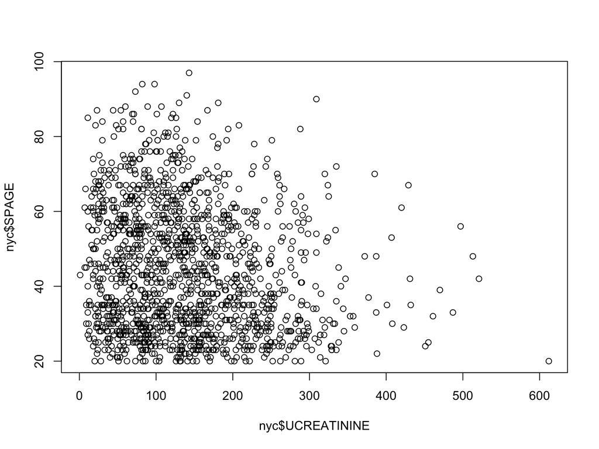

```r
plot(nyc$UCREATININE, nyc$SPAGE)
```

## Histograms

One of the most useful charts you may make is a histogram. A histogram is like a bar chart that displays the distribution of our data, basically with each bar presenting how many records fall into a subset of values. We use histograms to assess quickly if our data is normally distributed, or has a skew.

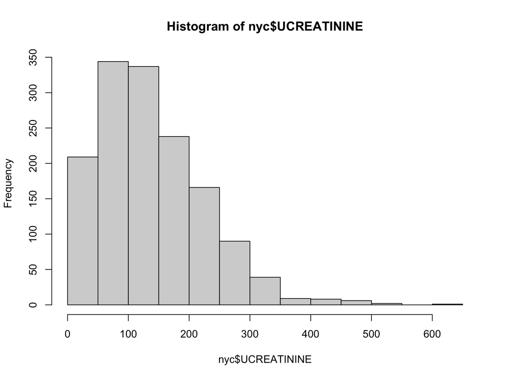

```r
hist(nyc$UCREATININE)
```

## Boxplot

Another chart that displays skew, as well as key values like median and quartiles is a boxplot:

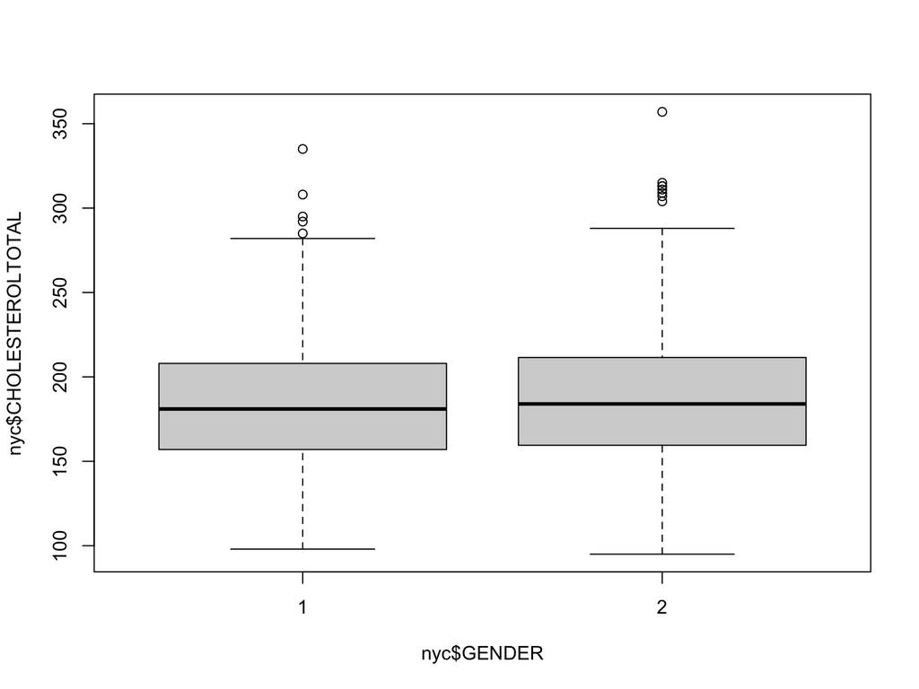

```r
boxplot(nyc$CHOLESTEROLTOTAL ~ nyc$GENDER, na.rm=T)
```

## Exercise:

Create a visualization to assess the skew of LEAD and of HDL levels.

## Subsets

Sometimes it is desirable to create a subset of a dataset that only contains those observations for which all there is a complete set of data, that is, no NAs. The na.omit() function will remove all observations that are not complete. So any row that has even a single NA will be deleted.

```r
no_na <- na.omit(nyc)
```

A more conservative approach is to remove only those observations that have NAs in key variables. For example, removing only those animals from full_data for whom there is an NA in the rem variable. This can be done using the function is.na(). In this case, we want to modify the function by sing the exclamation mark (logical NOT symbol), so that we can specify that we want all values that are NOT NA.

```r
has_cholesterol <- filter(nyc, !is.na(nyc$CHOLESTEROLTOTAL))
```

## Data Wrangling

```r
#install.packages("tidyverse",  repos =  "http://lib.stat.cmu.edu/R/CRAN/")

library(tidyverse)
```

#Subsetting Observations

NOTE: A single = is used for assignment, a double == is a logical operator and is checking to see if the statement is true

## Filter

The function filter() will need two arguments: 1) the data frame of interest 2) the logical condition to apply to the observations

Let’s filter for only diabetics

```r
diabetics  <-  filter(nyc,  nyc$DX_DBTS  ==  1)
```

## Logic and filtering

You can use logical operators (AND = &, OR = |, NOT = !) to create complex conditions:

```r
youngerDiabetics  <-  filter(nyc, nyc$DX_DBTS == 1  &  nyc$AGEGROUP  ==   1)
```

## Exercise:

Create a subset of the nyc_hanes dataset that has data only for the oldest group of diabetics that have a total cholesterol over 200. How many observations are in the resulting dataset?

## Continuing Your R Journey

This class has been a very basic introduction to working with data using R, but of course, there is much, much more that R can do. Fortunately, there are many ways to get help figuring out how to do new things in R, or troubleshooting when your R commands don’t work the way you think they should.

## Google is your friend

Getting a cryptic error message? Trying to figure out what function does what you are trying to do? Chances are very good that someone else has had your exact question and has gotten it answered! Google! And be as specific as possible! And look in your search results for the following sites:

1. Stack Overflow: site where people can ask questions and the community will answer. Essential resource!

(https://stackoverflow.com):

2)CRAN - The Comprehensive R Archive Network: basically the official site of R. Lots of documentation is hosted there, so you can usually find thorough descriptions of functions and packages

https://cran.r-project.org

3. R Bloggers: user-created tutorials on a variety of topics

https://www.r-bloggers.com

4. Quick-R: a clear guides to common operations in R, run by DataCamp which also has online classes on a freemium model

https://www.statmethods.net/index.html

## Recommended Books

These resources provide nice overview information to help you learn more about accomplishing general data tasks in R. 1) Field, Andy, Discovering Statistics Using R 2) Lander, Jared P. R for Everyone 3) Teetor, Paul. The R Cookbook: Proven Recipes for Data Analysis, Statistics, and Graphics 4) Grolemund, Garrett & Wickham, Hadley. R for Data Science

## Do Something (Anything!) in R

Find something that you have done or were going to do in a spreadsheet, or another programming language or just make something up to do, and do it in R instead.

1. Read in a file – read.csv(file = FILENAME.csv)
2. Use select or filter to grab a subset of the data
3. Use mean, max, etc. for descriptive statistics do not forget to use na.rm!
4. Save your code in an R file
5. Save your data, write.csv(DATAFRAME, file = “FILENAME.csv”)

If you do not remember how to do something, or want to do something that was not covered in class: Google it!! The only way to learn R is to use it!

## Practice

Try making a new dichotomous variable of triglycerides (coding it as 1 or 0 based on high or low value).

Make gender into a factored variable (hint: check the codebook at http://nychanes.org/data/ to see what value correspond to which number)

Convert DX_DBTS to a factor and make a frequency table. Bonus: make a cross table of DX_DBTS by Age Group

Find the mean amount of LEAD blood levels in the dataframe:

Try making a plot scatter plot of SPAGE vs Total Cholesterol.

Try making a histogram of the one variable in nyc.

Try making a boxplot of creatinine separated by diabetes status.